01 / 13

Documento de trabajo · Alain Pineda · Banco de México / Doctorado, Stanford 2024

# Seguridad social, sin empleo.

En 2016 México dio a 6.6 millones de estudiantes de escuela pública un número de seguridad social permanente antes de su primer empleo. Desde hace tiempo, los economistas temen que este tipo de beneficios *incentiven* la informalidad. Este hizo lo contrario.

Beneficios ligados a la escuela Informalidad Diseño por cohorte y estado Rambachan & Roth (2023)

Desliza

El problema

## Más de 2 mil millones de personas trabajan en empleos que el Estado no puede ver.

El empleo informal — sin registro, sin impuestos, sin protección — es la norma en los mercados laborales en desarrollo: más del 60% del empleo en el mundo, y cerca del 60% en México, donde la tasa por estado va de 40% a 80%. Significa no tener pensión, no tener cobertura médica, mayor exposición a la pobreza — y un gobierno que no puede gravar ni alcanzar a la mayoría de su propia fuerza laboral.

La tensión

Cada vez más gobiernos extienden la cobertura médica y la protección social a las personas **sin importar su situación laboral** — una buena idea en sí misma.

Pero una objeción de siempre dice que esto se revierte: si una red de protección ya no requiere un empleo formal, ¿para qué buscar uno? Los beneficios *desligados* del empleo formal podrían subsidiar la informalidad justo en el margen que la política busca reducir.

La política · 2016

## “Tienes IMSS”: ya lo tenías, solo no lo sabías.

Desde 1998, los estudiantes de bachillerato y educación superior en escuelas públicas tenían derecho, en el papel, a la cobertura médica nacional (IMSS), registrados en bloque por sus escuelas bajo números compartidos que nadie usaba. En 2016, una campaña conjunta del gobierno dio a cada uno de **6.6 millones de estudiantes** su propio número de seguridad social permanente — el mismo que usan los empleadores formales para contratar — y les dijo, con fuerza, que ya lo tenían.

[figure not shown]

Campaña nacional de afiliación “Tienes IMSS”Fuente: IMSS

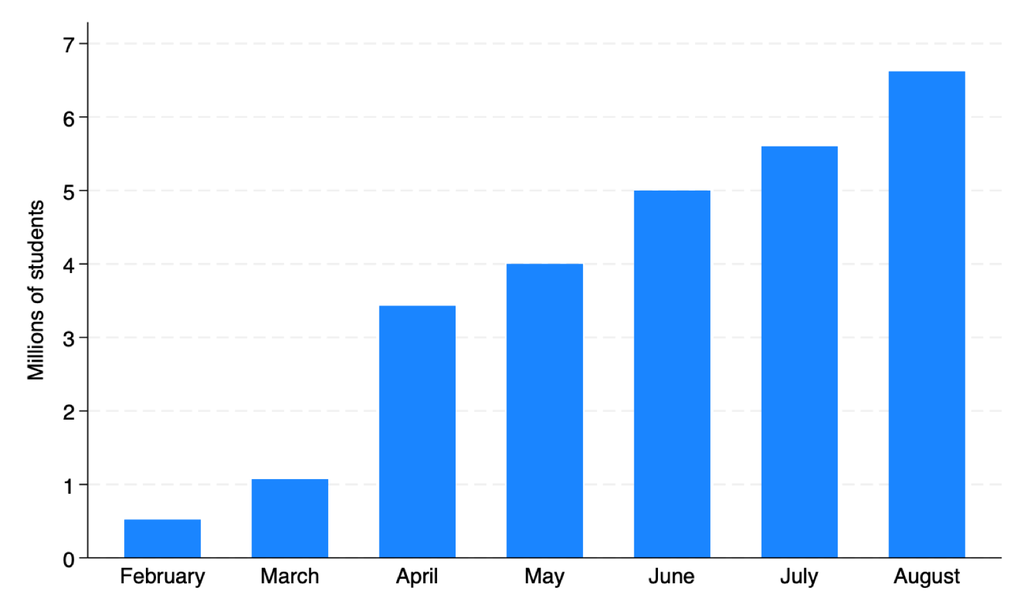

6.6 millones de estudiantes registrados individualmente en 6 mesesIMSS, 2016–17

Antes de los datos: tres hipótesis en competencia

## ¿Qué pasa cuando una red de protección deja de exigir un empleo?

Hipótesis 1

### La escuela desplaza al trabajo

Seguir inscrito se vuelve más valioso, así que los adolescentes trabajan menos. **↓ participación.**

Hipótesis 2

### La preocupación por desligar el beneficio

La cobertura médica se vuelve un complemento gratuito de un empleo informal. **↑ participación, ↓ formalidad.**

Hipótesis 3

### La hipótesis de la rampa de entrada

Tener el número de seguridad social que exige un empleo formal reduce la fricción para conseguir uno. **↑ formalidad.**

Las tres son plausibles *a priori*. Solo los datos sobre los resultados reales del mercado laboral pueden distinguir entre ellas.

El diseño

## Una implementación nacional no tiene grupo de control. Tiene un *gradiente* de control.

Todos fueron elegibles al mismo tiempo, así que no hay un estado que recibió la política y otro que no. Pero algunos estados partían de una informalidad mucho más alta que otros. Comparo cohortes de nacimiento que seguían en la escuela en 2016 con cohortes ligeramente mayores que ya habían salido — y pregunto si esa brecha entre cohortes se abre más en los estados donde la informalidad, y por tanto lo que está en juego, era mayor.

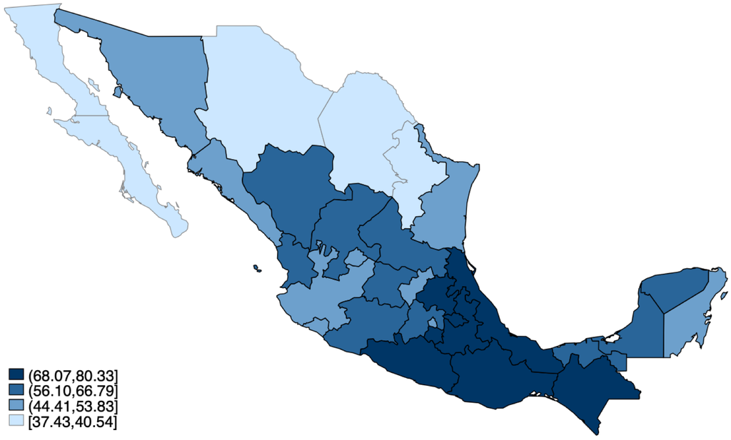

Tasa de informalidad previa a la política, por estado (2013–15)ENOE

**Cómo se construye la comparación, formalmente**

Diferencia de largo plazo, por estado *s* y trimestre *t*: Brecha<sub>s,t</sub> = β·I<sub>s,pre</sub> + X<sub>s,pre</sub>Γ + δ<sub>t</sub> + ε<sub>st</sub>, donde Brecha<sub>s,t</sub> es la brecha expuestos-menos-no-expuestos en un resultado del mercado laboral para el estado *s* en el trimestre *t*, I<sub>s,pre</sub> es la tasa de informalidad del estado en 2013–15 y δ<sub>t</sub> son efectos fijos de trimestre. Esta comparación limpia entre dos grupos es la razón por la que la diferencia de largo plazo excluye a las dos cohortes parcialmente expuestas (1999–2000, con uno y dos años de exposición en bachillerato, respectivamente). Una versión de panel agrupado sí las conserva: añade efectos fijos de cohorte, estado y trimestre, e interactúa la informalidad previa con una función de exposición *continua* a nivel cohorte, 2016–2019, de modo que la exposición parcial entra con un peso parcial en vez de excluirse. Las ponderaciones usan la raíz cuadrada de la población muestreada en cada celda; los errores estándar están clusterizados por estado (32 clústeres), y la inferencia sobre el coeficiente de interés se basa en valores p de bootstrap wild-cluster (pesos de Webb, 9,999 repeticiones).

El resultado principal

0.8–1.3

puntos porcentuales más de empleo formal,  
por cada punto de informalidad previa

Donde la informalidad partía más alta — justo donde la preocupación por “desligar” el beneficio debería pesar más — las cohortes expuestas se *alejaron más* de las no expuestas en empleo formal, no menos. Un estado con una desviación estándar más de informalidad que el promedio vio su brecha de formalidad entre cohortes ampliarse entre **11 y 16 puntos** — entre un tercio y la mitad de la brecha típica de 33 puntos entre cohortes expuestas y no expuestas.

De dónde viene el aumento

## No es un reacomodo. Es un giro hacia el empleo formal.

Un aumento en la *tasa* de formalidad podría simplemente significar que menos gente trabaja. Por eso, en lugar de tasas, descompongo la brecha expuesta-menos-no-expuesta en proporciones de toda la población de la cohorte — ocupados, formales, informales, desempleados, fuera de la fuerza laboral — de modo que las partes suman por construcción.

- La respuesta en participación fluye **por completo hacia el empleo**, no hacia el desempleo.
- El empleo formal absorbe **más que todo el incremento** (+0.90pp) — el empleo informal, de hecho, **cae** (−0.28pp).
- Por tipo de puesto: **todo es empleo subordinado y asalariado**. El trabajo por cuenta propia, formal o informal, no se mueve.

**De dónde vienen los 0.90pp de nuevos empleos formales**

Cerca de dos tercios (0.63pp) es **entrada neta** — en su mayoría personas que antes no participaban (0.59pp), más una caída pequeña e imprecisa en el desempleo. El tercio restante (0.28pp) es **reasignación**: trabajo que habría sido informal y ahora es formal.

Una versión placebo — fingiendo que las cohortes 1995–98 estaban “expuestas” frente a 1991–94 — encuentra un coeficiente de empleo formal de −0.06 (p = 0.61): nulo, una vez aplicados los mismos controles.

La duda obvia

## Tal vez los estados más pobres iban a alcanzar a los demás de todos modos.

La principal amenaza no es un factor de confusión en el sentido usual — es **reversión a la media**: estados con más informalidad (más pobres) convergiendo hacia los más ricos sin que exista ninguna política de por medio. Si esa convergencia ya existía entre cohortes demasiado grandes para haber sido expuestas, aparecería como una deriva en esta figura antes de que empezara la elegibilidad.

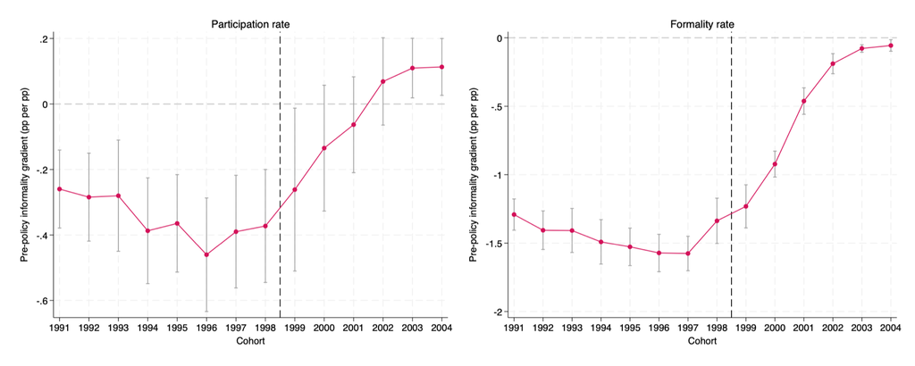

Gradiente por cohorte sobre la informalidad previaIC 95%, agrupado por estado

- Los gradientes se mantienen en una **banda estrecha y plana** entre las cohortes demasiado grandes para haber sido expuestas, y se rompen justo donde empieza la elegibilidad — no de forma gradual antes.
- Un diseño placebo aplicado por completo a cohortes no tratadas (1995–98 vs. 1991–94) arroja estimaciones **nulas o de signo contrario**.
- Antes de la implementación, las brechas entre estados de alta y baja informalidad se mueven **en paralelo**, trimestre a trimestre.

Esto tranquiliza — pero juzgar una gráfica a simple vista es una prueba débil con solo 32 estados, y tratarla como filtro distorsionaría la inferencia que sigue. Por eso el siguiente paso no pregunta *si* el supuesto se cumple. Pregunta *cuánto podría fallar sin que el resultado deje de sostenerse.*

Una mirada más profunda · Rambachan & Roth (2023)

## Deja de preguntar “¿las tendencias siguieron paralelas?”. Pregunta “¿qué tan lejos podrían estar?”.

Todo diseño de comparación entre cohortes como este descansa en un supuesto: sin la política, la tendencia de las cohortes no tratadas es un buen sustituto de lo que *habrían hecho* las cohortes tratadas. Nadie puede observar ese contrafactual directamente — y con solo 32 estados, una gráfica como la de la diapositiva anterior no puede descartar una violación lo bastante grande como para importar.

La solución de Rambachan y Roth: en lugar de suponer que la violación es exactamente cero, dejar que sea *cualquier valor hasta un tamaño M̄*, escalado respecto a la mayor variación observada entre cohortes que no pudieron haber sido tratadas. Luego preguntar — conforme M̄ crece desde cero — en qué punto el conjunto de confianza del efecto empieza a incluir el cero. **Ese punto de cruce es el valor de ruptura.** Uno grande significa que el resultado sobreviviría una violación mucho mayor que cualquiera visible en los datos; uno pequeño significa que es frágil.

No añade un supuesto nuevo Evita el sesgo de preprueba

**Notas de implementación**

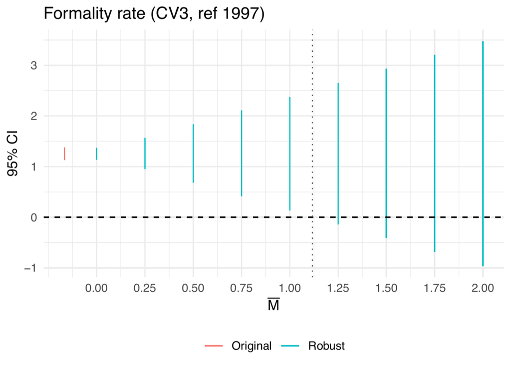

Formalidad: conjunto de confianza robustoΔ<sup>RM</sup>(M̄), cohorte de referencia 1997

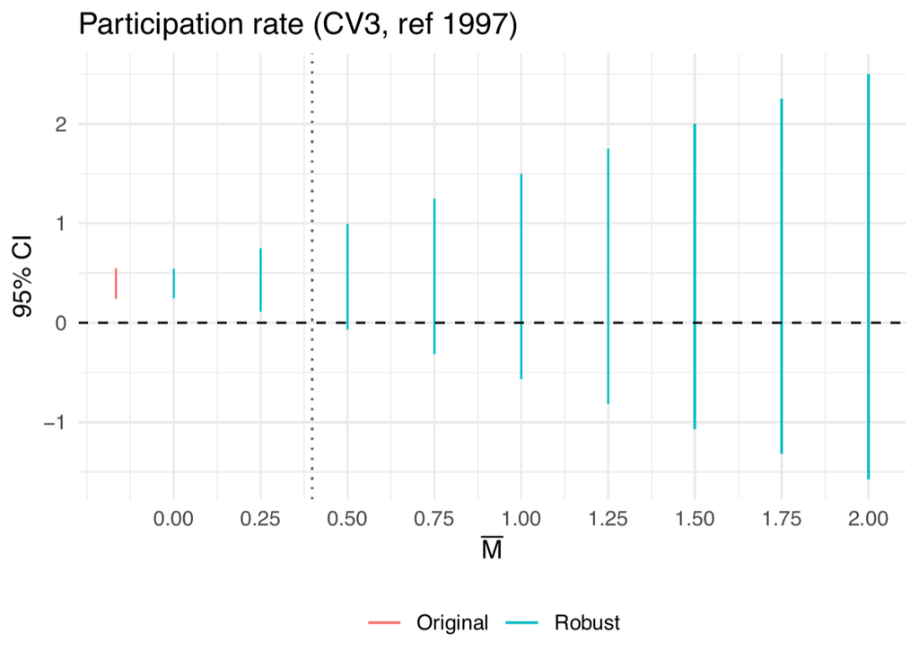

Participación: conjunto de confianza robustoΔ<sup>RM</sup>(M̄), cohorte de referencia 1997

¿Por qué formalidad, y no el colchón informal?

## Un número, no un subsidio.

El patrón apunta a **saliencia y fricción administrativa**, no a un cambio en el precio del trabajo informal. La política no hizo más atractivos los empleos informales — hizo más fácil conseguir uno formal, al poner en manos de los estudiantes el trámite que exige la contratación formal, antes de que lo necesitaran.

### Solo empleo asalariado

Todo el aumento en empleo formal es empleo subordinado y asalariado. El trabajo formal por cuenta propia no se mueve — justo lo que predice una historia de fricción en la contratación, y no lo que produciría un cambio en el retorno de trabajar por cuenta propia.

### Igual para todos

Los efectos son similares para mujeres y hombres, para quienes siguen estudiando y quienes no, y para jóvenes con jefe de hogar formal o informal — se sostienen incluso al excluir por completo a los trabajadores por cuenta propia.

### Corroborado de forma independiente

ENILEMS, una encuesta distinta a egresados de bachillerato con una medida más precisa de exposición a la escuela pública, reproduce por su cuenta el resultado en participación.

Qué más dicen los datos

## Sin costos ocultos, por ahora.

### Inscripción escolar

No hay evidencia de que el empleo formal haya sacado a los estudiantes de la escuela — lo que responde a la primera de las tres hipótesis iniciales.

### Ingreso

Positivo pero económicamente pequeño, y no significativo estadísticamente — este es un paper sobre la *condición formal* del empleo, no sobre ingresos.

### Definición alternativa de informalidad

Al restringir la medida de informalidad solo a *empleados* informales (recalculándola entre trabajadores subordinados y remunerados, con lo que salen quienes trabajan por cuenta propia, los empleadores y quienes trabajan sin pago), el signo y la significancia se mantienen, con estimaciones más ruidosas.

La lección de política

## Nunca se trató realmente de desligar el beneficio. Se trató de cómo se entrega.

El derecho existía desde 1998. Las escuelas siempre habían llevado los listados. Lo que cambió en 2016 no fue *si* el beneficio exigía un empleo — nunca lo exigió — sino *cómo llegaba a las personas*: adherido a cada estudiante de forma individual, dentro del sistema contributivo, con el identificador exacto que exige la contratación formal, antes de su primer empleo. Un beneficio que pudo haber subsidiado la informalidad funcionó, en cambio, como rampa de entrada — hacia el lado formal.

La misma lógica debería aplicar en cualquier lugar donde la protección social viaje por un canal — un registro, una identificación, una cuenta de pago — que también reduzca el costo de una transacción formal.

Gracias

## Seguridad Social sin Empleo

Beneficios ligados a la escuela y formalización temprana en México

AutorAlain Pineda · Banco de México, Dirección General de Investigación Económica

Contactoalain.pineda@banxico.org.mx

MétodoRambachan, A. & Roth, J. (2023). “A More Credible Approach to Parallel Trends.” *Review of Economic Studies*, 90(5), 2555–2591.

Las opiniones expresadas son responsabilidad exclusiva del autor y no reflejan necesariamente las de Banco de México ni las de su Junta de Gobierno.